Project Report

# GLOBAL WATER SCARCITY & DROUGHT RISK

Ketan Pimparkar | FA'19 Data Visualization | IU MS Data Science

## Abstract

> Water scarcity is the lack of fresh water resources to meet water demand. It affects every continent and was listed in 2019 by the World Economic Forum as one of the largest global risks in terms of potential impact over the next decade. Two-thirds of the global population (4 billion people) live under conditions of severe water scarcity at least 1 month of the year. Half a billion people in the world face severe water scarcity all year round. Half of the world’s largest cities experience water scarcity.  
> [Water scarcity Wiki](https://en.wikipedia.org/wiki/Water_scarcity)

Water is essential for all living beings. Human race relies on water for drinking needs, food, medicine, electricity, manufacturing among other needs. Access to clean water is a basic need for humans. Water sources and reservoirs have played vital role in the development of human cultures.

Even though water plays such an important role in the existence and development of human beings, we are currently facing grave problems of water scarcity and drought risks. Communicating this risk to wider audience is now of more importance than ever before.

Science direct explains the problem of water scarcity by taking into consideration the impact of human water consumption, natural factors and current context of this problem:

> Water scarcity arises in situations where there is insufficient water to simultaneously support both human and ecosystem water needs (White, 2014). Most often this arises as a result of a basic lack of water (i.e., physical water scarcity), but it may also result from a lack of suitable infrastructure to provide access to what might otherwise be considered ample available water resources, which is referred to as economic water scarcity. Physical water scarcity may occur as a result of both natural phenomena (e.g., aridity, drought) as well as from human influences (e.g., desertification, water storage; Pereira et al., 2009; White, 2014), although these influences are often coupled. For example, the process of desertification often commences as a result of water overuse during periods of temporary drought; droughts are more common in arid regions (McMahon et al., 1992).  
> [Water scarcity - Science Direct](https://www.sciencedirect.com/topics/earth-and-planetary-sciences/water-scarcity)

This visualization project aims to convey these risks to the audience to create awareness about water shortage and the importance of water conservation. The project will visualize the water scarcity data from various sources to demonstrate the adverse conditions of water shortage and drought.

## Motivation

Around 71% of Earth's surface is covered by water and there are huge water reservoirs such as rivers, lakes, glaciers around us. But still we are facing water scarcity. Countries such as Australia, Brazil, India, China, Syria have faced very severe impact of drought.[[2]](https://www.wri.org/blog/2015/06/global-tour-7-recent-droughts)

> A mere 0.014% of all water on Earth is both fresh and easily accessible. Of the remaining water, 97% is saline and a little less than 3% is hard to access. Technically, there is a sufficient amount of freshwater on a global scale. However, due to unequal distribution (exacerbated by climate change) resulting in some very wet and some very dry geographic locations, plus a sharp rise in global freshwater demand in recent decades driven by industry, humanity is facing a water crisis. Demand is expected to outstrip supply by 40% in 2030, if current trends continue.  
> [Water scarcity Wiki](https://en.wikipedia.org/wiki/Water_scarcity)

Water scarcity and drought have huge ecological and sociological impact. These conditions affect various aspects of human life, such as[[3]](http://www.eschooltoday.com/global-water-scarcity/effects-of-water-shortage.html):

**Health**  
Water scarcity forces the community to use less clean or even contaminated water for drinking, cooking. This has direct impact on overall health of individuals of the society. Water is important for cleaning process as well. Shortage of water results in sanitation and cleanliness related problems.

**Food production**  
Water is used in irrigation of crops. Additionally, water is used in processing and production of packaged food. Water scarcity has direct impact on these processes resulting in lower food production.

**Poverty**  
In societies where agriculture is the main industry providing jobs and income to individuals, the impact of water shortage is very threatening. Community spends most of the time in search of clean water than on betterment of the society.

One of the factor that motivated me to perform analysis on the topic of water scarcity and droughts is the socioeconomic impact this problem has on agriculture based countries like India. Agriculture sector is the only livelihood to the two-third of India's population which gives employment to the 57% of work force and is a raw material source to large number of industries. Impact of droughts on the lives of Indian farmers is so deep that it has resulted in suicides of farmers at epidemic proportions. Suicides among farmer community is a major concern in various state of India. Approximately 3.4 million cotton farmers occupy a small region in India call "Vidarbha" and 95% of them struggle with massive debt [[4]](https://www.ncbi.nlm.nih.gov/pmc/articles/PMC2738339/). Incidence of farmers ending their lives in this region had hit epidemic like proportions recently.

> In a country of 70 million farmers, it is 10 in every 100,000 farmers committing suicide. This is higher than the total national suicide rate. The number of farmers committing suicide in India is more than twice of the total number of suicides being committed in the top 100 countries on the suicide list! This indeed is worrying factor. The Government's measures including waiving off loans, construction of dams, and other assisting measures have not produced positive results so far.  
> [Suicides among farmers in India](https://www.ncbi.nlm.nih.gov/pmc/articles/PMC2738339/)

[figure not shown]

[Chart 1: Baseline water stress in India](https://wriorg.s3.amazonaws.com/s3fs-public/uploads/India_Water_tool_blog_graphics-01.png)

This is visualization project is an effort to emphasize on the *need for action*. Every important decision made by us depends on relevant data. In order to convey the wide spread nature of the water scarcity and drought risks to global leaders, it is necessary that this data is represented objectively. In order to represent the data objectively, this project relies on the Aqueduct™ water risk framework provided by World Resources Institute [[1]](https://www.wri.org/aqueduct).

> WRI’s Aqueduct™ information platform compiles advances in hydrological modeling,  
> remotely sensed data, and published data sets into a freely accessible online platform.

Aqueduct water risk framework transforms various data sources into water risk indicators. This project focuses on utilizing these indicators to convey the vast spread of water scarcity. WRI provides an online tool which explores this data and visualizes it in a geospatial manner.

> Aqueduct™ Water Risk Atlas

## Related work

Various resources are available where the current state of water scarcity is visualized in very effective manners. These plots do commendable jobs in conveying the risks we are facing today due to water shortage. Couple of such visualizations are mentioned as below:

### U.S. Drought Monitor

#### Overview

This is geospatial visualization of current drought condition in the U.S. It displays the information about drought types, intesity of the drought and source of the data. The type and intensity of the drought is overlayed on the map of U.S. indicating conditions at various geographical locations in the U.S.

#### Explanation of the data

This visualization uses drought type, drought intensity at various geographic locations in the U.S. It uses shades of red and yellow to convey the intensity of drought. The data is collected by government agencies monitoring the drought conditions.

#### Visualization technique and design

This geospatial visualization clearly conveys following data:

- which states are affected by drought situation
- what is the severity of drought in these states
- if this is a log term problem or a short term problem faced by the state.  
  Colors used in this visualization are easily distinguishable. They portray affected areas clearly. Mention of all government agencies involved in data collection and the author gives credibility to the data represented in this plot. This visualization has included Alaska, Hawaii, Puerto Rico as well indicating that those islands are also affected by the drought conditions. Time stamp of the visualization helps to convey how recent the data is. And the visualization has also provided viewers a way to access additional information via a website.

[figure not shown]

[Chart 2: U.S. Drought monitor](https://droughtmonitor.unl.edu/data/jpg/20190917/20190917_usdm.jpg)

### Global view of duration of water scarcity

#### Overview

This is a visualization of duration of water scarcity in the world. It uses map of the world and plots indicators of scarcity with red and green colors. Purpose of the visualization appears to indiate which parts of the world are affected by water scarcity and the intensity of this scarcity. Visualization includes a scale to relate the color used with the period for which the region faced water scarcity. It succeeds in providing an overview of the water scarcity in various parts of the world.

#### Explanation of the data

The visualization uses map of the world. Data visualized on this map is count of months when water scarcity was greater than 100%. This count is then converted to categorical values by choosing ranges. Each range is assigned a color which is then added as a layer on top of the global map. The data from the year 2016 is used for this visualization.

#### Visualization technique and design

Main medium of communication in this visualization is color. There is a scale which indicates range of drought affected months represented by correponding color. It successfully shows us which continents are affected the most by water scarcity.  
This visualization gives overall idea of spread of water scarcity, but it fails to provide us numbers behind the visual. It would benefit a lot by including some interactivity. Due to small scale of the graph, we don't get any idea about the condition of drought in a particular country. The visualization uses red and green colors which are not visible to color blind people. It doesn't clearly explain what does 'water scarcity greater than 100%' mean. It also fails to convey if this is a permanent situation at the given countries or a temporary situation. Display of time trend would give us better idea of the issue.

[figure not shown]

Chart 3: Map showing the global distribution of regions  
affected by water scarcity. Reprinted from Mekonnen, M.M., Hoekstra,  
A.Y., 2016. Four billion people facing severe water scarcity. Sci. Adv. 2.

## Data Visualizations

Main objective of this project is to demonstrate how wide spread the problem of water scarcity and drought is. The project aims at showcasing quantified attributes of water scarsity with the help of geospatial visualizations to convey the impact of water scarcity. This approach will help perform a comparative analysis of the problem faced by the world. Such analysis will also generate healthy competition between communities to perform better to conserve water and control the adverse effect of water scarcity.

The project also aims to analyze available data to suggest remedial measures on the drought issue.

WRI classifies the water risk in three major categories [[5]](https://wriorg.s3.amazonaws.com/s3fs-public/aqueduct-30-updated-decision-relevant-global-water-risk-indicators_0.pdf)

- Physical Risk Quantity
- Physical Risk Quality
- Regulatory and Reputational Risk

This project focuses on attributes of "Physical Risk Quantity". In order to achive objectives of this project, we first access the dataset from [Aqueduct Global Maps 3.0 Data](https://www.wri.org/resources/data-sets/aqueduct-global-maps-30-data).

### 1. Interactive choropleth for comparative analysis of total water risk scores

In this visualization, we analyze the data provided by Aqueduct Global Maps 3.0. We use the weighted overall water risk available in this dataset.

#### Dataset

- [Water risk scores for geographical areas](https://wri-projects.s3.amazonaws.com/Aqueduct30/finalData/Y2019M07D12_Aqueduct30_V01.zip)
- [Description of the dataset](https://github.com/wri/aqueduct30_data_download/blob/master/metadata.md)
- [Shapefile for the World map](https://github.com/nvkelso/natural-earth-vector/blob/master/110m_cultural/ne_110m_admin_0_countries.shp)

#### Data extraction and wrangling

- The .csv provided by the dataset did not contain any geographical data which could be used in a geospatial mapping. However, the dataset provided a QGIS project file (y2019m07d15_baseline_annual_v01.qgz). This file was accessed and extracted in .csv format using `QGIS tool`.
- QGIS tool adds polygon of cordinates, to mark areas provided in the dataset. These areas correponded to the area covered by hydrological basins. This exercise resulted in a very bulky ( > 1GB) file which could not be handled by using `pandas` and `altair`. This could be due to resource limitations of local machine used for this analysis as well.
- QGIS tool was then used to extract very limited attributes of the data in .csv format. Geographical data was not extracted from QGIS. Instead of QGIS, I used `geopandas` to get the geographical data of each country.
- Additionally, in the original data there were multiple records for each country corresponding to various hydrological basins. This data was used to calcultae average weighted overall water risk scre of each country.
- [Code of this data wrangling process](https://github.com/kpimparkar/Data-Visualization/blob/master/DVIZ_Project_data_prep.html)

#### Design and Vizualization technique

- The choroleth uses `equalEarth` map projection. It uses reversed `viridis` color pallete to show the data. As usage of red-green axis is avoided, this visualization is more accessible.
- Color scheme allows users to compare water scores of various countries very easily.
- A continuous risk score scale ranging from 0 (very low) to 4 (very high) is used.
- Antarctica is eliminated from the choropleth as there is no data available.
- Other countries for which data is not available are shown with white fill.
- The choropleth is interactive which allows users to hover over a country and see the water risk score along with country name.

**Iterative analysis and Failed attempts**

- The dataset provided by Aqueduct 3.0 contains water risk scores for each hydrological basins. Each such record has cordinates of endpoints of geographical polygon covering the area surrounding these basins. This made the dataset very huge.
- First attempt to vizualize this data as it is was unseccessful due do its sheer volume and limitation of computational resources of the local machine used for this project.
- In second attempt, QGIS tool was used to calculate centroid of each of these polygons which could be mapped with geojson holding boundaries of each country. This attempt also was unsuccessful due to limitation of computational resources of the local machine.
- This problem was solved by using `pandas groupby` to find mean score of all basins belonging to a specific country.
- Initial objective of this vizualization was to show `orthographic projection` of the data in an interactive manner. This objective was dropped because the slider added to control rotation of the orthographic projection could not be integrated with the map. This vizualization is added data preparation [notebook for reference](https://github.com/kpimparkar/Data-Visualization/blob/master/DVIZ_Project_data_prep.html).

[interactive chart not shown]

### 2. Interactive scatter plot to check relation between GDP and Agricultural Fresh water withdrawal

Consumtion of water is very high for agricultural uses. In order to search any possible remedy of the water risk problem, we verify the relation between the usage of the water for agricultural purposes and the GDP of the country. Such analysis would help us identify which countries can optimize the agricultural water consumption to reduce water risk. It will also help us identify any pattern between the GDP of the countries and the agircultural water consumption.

#### Dataset

- Data published by: World Bank – World Development Indicators
- Data publisher's source: Food and Agriculture Organization, AQUASTAT data.
- Link: http://data.worldbank.org/data-catalog/world-development-indicators
- Data taken from: https://ourworldindata.org/water-use-stress

#### Data extraction and wrangling

This data set was in clean format, hence no data wrangling was required.

#### Design and Vizualization technique

- This scatter plot allows users to scroll through years from 1969 to 2018 and vizualize the relation between GDP and the Agricultural Fresh water withdrawal.
- This visualization varies the dot/bubble as per the population of the country.
- On mouseover, this visualization also shows details such as country name, GDP, % of agricultural water withdrawal and the year.
- Limitation of the data: The data is available for limited set of years. Not all countries have the data for all years.
- With this data vizualization it is visible that countries with lower GDP tend to have higher usage of water for agricultural purposes.
- Hence these countries can optimize this water usage to mitigate water risk.

[interactive chart not shown]

### 3. Jointplot to check if water risk is just due to to water scarcity

Another aspect of the water risk score is to see if the water risk is just due to water shortage. For this purpose, two joint plots are plotted:

- overall water risk score and the riverine flood risk score
- drought risk score and riverine flood risk score

#### Dataset

- [Water risk scores for geographical areas](https://wri-projects.s3.amazonaws.com/Aqueduct30/finalData/Y2019M07D12_Aqueduct30_V01.zip)
- [Description of the dataset](https://github.com/wri/aqueduct30_data_download/blob/master/metadata.md)

#### Data wrangling

- Available dataset contains more than 250 attributes. For this visualization, very few attributes are extracted from the original dataset.
- This data is cleaned further by droppung NULL values.
- Subset of data for India is created.

#### Design and visualization technique

- These are simple joint plots with KDE plots on the edges.
- These clearly indicate the relationship between the two parameters involved.
- This type of analysis varies a lot depending upon the climate conditions and geographic location of a country. Hence a subset of the data is created for India.
- Analysis of these joint plots for India indicate that India has high riverine floood risk and high drought risk. Which means, if the water responsible for riverine floods is effectively rerouted or stored then it can help India to mitigate the risk of riverine floods as well as droughts.

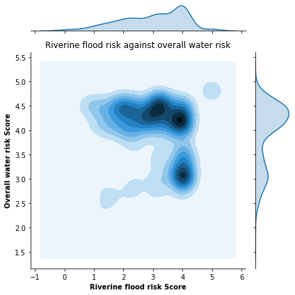

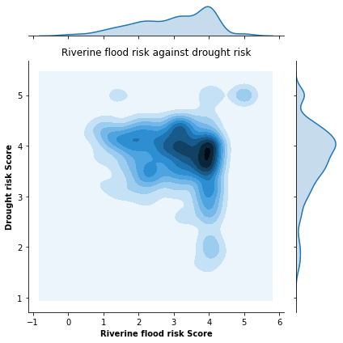

## Project conclusion

- From the comparison of water risk scores of various countries it is seen that under-developed and developing countries face higher water risk.
- It is also visible that countries with lower GDP tend to have higher usage of water for agricultural purposes. Hence these countries can optimize this water usage to mitigate water risk.
- Analysis of joint plots for India indicate that India has high riverine floood risk and high drought risk as well. Which means, if the water responsible for riverine floods is effectively rerouted or stored then it can help India to mitigate the risk of riverine floods as well as droughts.

## Future steps

- Combine the available data with water footprints and create a mechanism that would highlight factors responsible for creation of economic water scarcity.
- Suggest achievable corrective measures to control adverse effects of water scarcity.
- Convert the choropleth in an interactive orthographic projection

## References

[1] [WRI Aqueduct](https://www.wri.org/aqueduct)  
[2] [Recent droughts ERI](https://www.wri.org/blog/2015/06/global-tour-7-recent-droughts)  
[3] [Effects of water shortage](http://www.eschooltoday.com/global-water-scarcity/effects-of-water-shortage.html)  
[4] [Suicides among farmers in India](https://www.ncbi.nlm.nih.gov/pmc/articles/PMC2738339/)  
[5] [Aqueduct 3.0: global water risk indicators](https://wriorg.s3.amazonaws.com/s3fs-public/aqueduct-30-updated-decision-relevant-global-water-risk-indicators_0.pdf)  
[6] [Aqueduct 3.0 Water Risk Atlas Metadata](https://github.com/wri/aqueduct30_data_download/blob/master/metadata.md)  
[7] [Our world in data: Water use and sanitation](https://ourworldindata.org/water-use-sanitation#water-stress-and-scarcity)  
[8] [Our world in data: Water use stress](https://ourworldindata.org/water-use-stress)  
[9] [Altair interactive visualization](https://altair-viz.github.io/gallery/us_population_over_time.html)